# TargetCNV-ML: Reporte de Entrenamiento y Evaluación de Modelos

Colinealidad de Predictores, Cortes de Youden, Validación Cruzada Determinista y Explicabilidad SHAP

Author

TargetCNV-ML

Published

November 3, 2026

## 1 Resumen de Datos de Referencia y Etiquetado Espacial

El conjunto de entrenamiento proviene de la intersección espacial estricta por cromosoma y hebra entre los contigs nucleares ensamblados por CAPTUS (`protein_match:NUC`) y la anotación génica del genoma de referencia, seguida de la resolución de redundancias técnicas intra-locus.

**Fuente del Genoma de Referencia:** Reportado y publicado en el portal Solanum Pan-Genomics (https://solpangenomics.com/dist/pages/downloads/index.php), en Solanaceae Genomics Network (https://solgenomics.net/ftp/genomes/Solanum_pangenomics/) y en NCBI BioProject bajo [Accession: PRJNA1073673](https://www.ncbi.nlm.nih.gov/bioproject/PRJNA1073673).  
**Fuente de Homología y Datos Génicos:** Benoit, M. et al.: , 2025; Solanum pan-genetics reveals paralogues as contingencies in crop engineering; Nature; 640 (8057): 135–145; [doi:10.1038/s41586-025-08619-6](https://doi.org/10.1038/s41586-025-08619-6) (Espacio de homología OG_ID directo 1:1).  
**Archivos de Origen:** `data_prepared.rds`

Secuencias Evaluadas

184

Marcadores nucleares (NUC)

Verdaderos Positivos (TP)

87 (47.3%)

Homólogos validados espacialmente

Falsos Positivos (FP)

97 (52.7%)

Ruido intergénico o redundancia

Métodos Evaluados

24

4 Youden + Heurístico + ML

| Grupo | Secuencias | Proporción (%) | Media % Recuperado | Media % Identidad | Media Score | Media WScore |
| --- | --- | --- | --- | --- | --- | --- |
| FP (Falso Positivo) | 97 | 52.72 | 60.26 | 75.96 | 0.324 | 0.449 |
| TP (Verdadero Positivo) | 87 | 47.28 | 94.92 | 94.21 | 0.857 | 0.879 |

## 2 Distribución de Predictores, Cortes de Youden y Colinealidad de Spearman

Las cuatro métricas continuas de CAPTUS (`pct_recovered`, `pct_identity`, `score` y `wscore`) presentan distinto grado de acoplamiento estadístico. El diagnóstico de correlación por rangos de Spearman ($\rho$) cuantifica la dependencia monótona entre predictores antes del ajuste supervisado y justifica el uso de algoritmos con regularización ($L_1/L_2$ en `ElasticNet`) o particionamiento recursivo.

**Densidades y Umbrales de Youden**

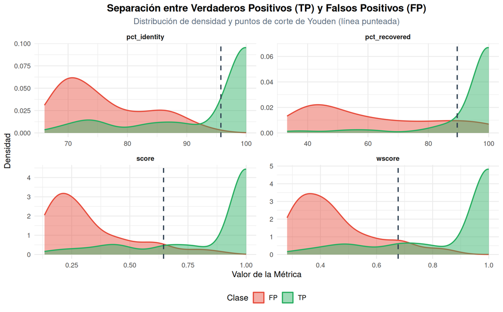

**Matriz de Colinealidad de Spearman**

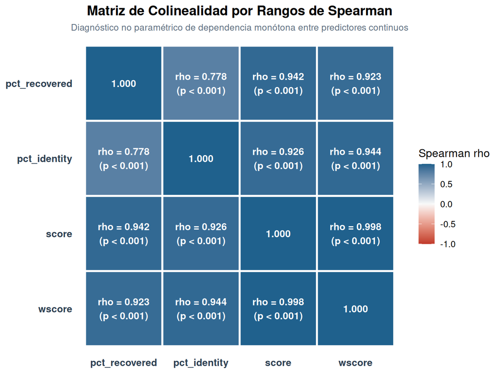

**Tabla de Correlaciones por Pares (\(\rho\) de Spearman)**

| Variable_1 | Variable_2 | N_Pares | Spearman_Rho | P_Valor | Colinealidad |
| --- | --- | --- | --- | --- | --- |
| score | wscore | 184 | 0.9977 | 2.013e-215 | Alta (\|rho\| &gt;= 0.85) |
| pct_identity | wscore | 184 | 0.9439 | 1.539e-89 | Alta (\|rho\| &gt;= 0.85) |
| pct_recovered | score | 184 | 0.9417 | 4.685e-88 | Alta (\|rho\| &gt;= 0.85) |
| pct_identity | score | 184 | 0.9264 | 4.033e-79 | Alta (\|rho\| &gt;= 0.85) |
| pct_recovered | wscore | 184 | 0.9233 | 1.538e-77 | Alta (\|rho\| &gt;= 0.85) |
| pct_recovered | pct_identity | 184 | 0.7776 | 1.612e-38 | Moderada (0.60 &lt;= \|rho\| &lt; 0.85) |

**Puntos de Corte Univariados de Youden y Modelo Heurístico**

| Modelo | Mejor_Version_FDR | Exactitud | Exactitud_Balanceada | Sensibilidad | Especificidad | Precision | VPN | FDR | F1_Score | MCC | Kappa | ROC_AUC | TP | FP | FN | TN | Umbral | Indice_Youden_J |
| --- | --- | --- | --- | --- | --- | --- | --- | --- | --- | --- | --- | --- | --- | --- | --- | --- | --- | --- |
| Youden_pct_recovered | Invariante (regla fija) | 87.5 | 87.37 | 85.06 | 89.69 | 88.1 | 87 | 11.9 | 0.865 | 0.749 | 0.749 | 0.914 | 74 | 10 | 13 | 87 | 89.555 | 0.747 |
| Youden_pct_identity | Invariante (regla fija) | 86.96 | 86.21 | 72.41 | 100 | 100 | 80.17 | 0 | 0.84 | 0.762 | 0.735 | 0.901 | 63 | 0 | 24 | 97 | 95.745 | 0.724 |
| Youden_score | Invariante (regla fija) | 88.04 | 87.77 | 82.76 | 92.78 | 91.14 | 85.71 | 8.86 | 0.867 | 0.762 | 0.759 | 0.933 | 72 | 7 | 15 | 90 | 0.645 | 0.755 |
| Youden_wscore | Invariante (regla fija) | 86.96 | 86.8 | 83.91 | 89.69 | 87.95 | 86.14 | 12.05 | 0.859 | 0.738 | 0.738 | 0.928 | 73 | 10 | 14 | 87 | 0.677 | 0.736 |

## 3 Benchmark Multimétrica y Diagnóstico Individual por Escenario

Se comparan dos regímenes de validación cruzada estratificada con particiones y semillas deterministas: el **Escenario Balanceado** (submuestreo aleatorio dentro de cada pliegue para equilibrar sensibilidad y especificidad) y el **Escenario Desbalanceado** (proporción natural de clases).

**Escenario Balanceado**

[interactive chart not shown]

**Ver Benchmark Completo de Todos los Métodos (Escenario Balanceado)**

[interactive chart not shown]

Los métodos marcados con `*` obtienen menor tasa de descubrimiento falso (FDR) o mayor índice compuesto en el escenario alternativo.

| Modelo | Mejor_Version_FDR | Exactitud | Exactitud_Balanceada | Sensibilidad | Especificidad | Precision | VPN | FDR | F1_Score | MCC | Kappa | ROC_AUC | TP | FP | FN | TN |
| --- | --- | --- | --- | --- | --- | --- | --- | --- | --- | --- | --- | --- | --- | --- | --- | --- |
| NaiveBayes | Equivalente en ambos (FDR: 8.00%) | 86.96 | 86.56 | 79.31 | 93.81 | 92 | 83.49 | 8 | 0.852 | 0.743 | 0.736 | 0.934 | 69 | 6 | 18 | 91 |
| SVM_Polinomial | Óptimo en Balanceado (FDR: 7.89% vs 23.30% \| Índice: 0.880 vs 0.787) | 87.5 | 87.14 | 80.46 | 93.81 | 92.11 | 84.26 | 7.89 | 0.859 | 0.753 | 0.748 | 0.934 | 70 | 6 | 17 | 91 |
| Youden_score | Invariante (regla fija) | 88.04 | 87.77 | 82.76 | 92.78 | 91.14 | 85.71 | 8.86 | 0.867 | 0.762 | 0.759 | 0.933 | 72 | 7 | 15 | 90 |
| Ensamble_Stacking | Óptimo en Balanceado (FDR: 7.69% vs 8.75% \| Índice: 0.887 vs 0.883) | 88.59 | 88.29 | 82.76 | 93.81 | 92.31 | 85.85 | 7.69 | 0.873 | 0.774 | 0.77 | 0.932 | 72 | 6 | 15 | 91 |
| ElasticNet * | * Mejor en Desbalanceado (FDR: 14.12% vs 15.12% \| Índice: 0.842 vs 0.835) | 85.33 | 85.25 | 83.91 | 86.6 | 84.88 | 85.71 | 15.12 | 0.844 | 0.706 | 0.705 | 0.93 | 73 | 13 | 14 | 84 |
| Youden_wscore | Invariante (regla fija) | 86.96 | 86.8 | 83.91 | 89.69 | 87.95 | 86.14 | 12.05 | 0.859 | 0.738 | 0.738 | 0.928 | 73 | 10 | 14 | 87 |
| Red_Neuronal | Óptimo en Balanceado (FDR: 10.98% vs 13.58% \| Índice: 0.866 vs 0.836) | 87.5 | 87.31 | 83.91 | 90.72 | 89.02 | 86.27 | 10.98 | 0.864 | 0.75 | 0.749 | 0.927 | 73 | 9 | 14 | 88 |
| SVM_Lineal * | * Mejor en Desbalanceado (FDR: 10.98% vs 13.10% \| Índice: 0.865 vs 0.850) | 86.41 | 86.28 | 83.91 | 88.66 | 86.9 | 86 | 13.1 | 0.854 | 0.727 | 0.727 | 0.925 | 73 | 11 | 14 | 86 |
| MLP_Regularizado * | * Mejor en Desbalanceado (FDR: 7.69% vs 11.11% \| Índice: 0.886 vs 0.861) | 86.96 | 86.74 | 82.76 | 90.72 | 88.89 | 85.44 | 11.11 | 0.857 | 0.739 | 0.737 | 0.923 | 72 | 9 | 15 | 88 |
| Red_Neuronal_Bag * | * Mejor en Desbalanceado (FDR: 7.69% vs 10.00% \| Índice: 0.886 vs 0.870) | 87.5 | 87.26 | 82.76 | 91.75 | 90 | 85.58 | 10 | 0.862 | 0.75 | 0.748 | 0.923 | 72 | 8 | 15 | 89 |

[output cut: 14 more lines]

#### 3.0.1 Matrices de Confusión e Importancia de Variables (Escenario Balanceado)

**Resumen: Top 6 (2 Youden + Heurístico + 3 ML)**

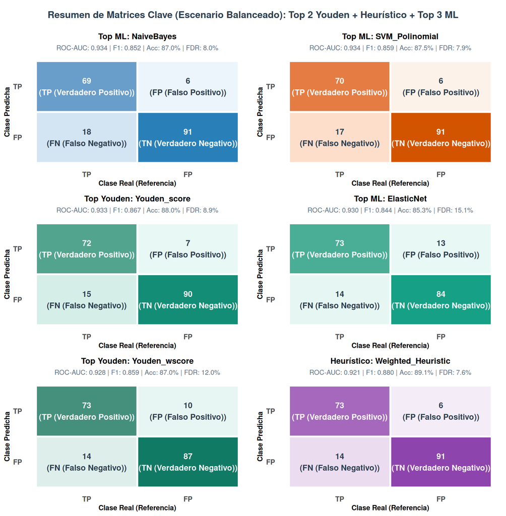

**NaiveBayes**

NaiveBayes (Escenario Balanceado): F1: 0.852 | ROC-AUC: 0.934 | Exactitud Bal.: 86.56% | Sensibilidad: 79.31% | Especificidad: 93.81% | Precisión: 92.00% | FDR: 8.00%

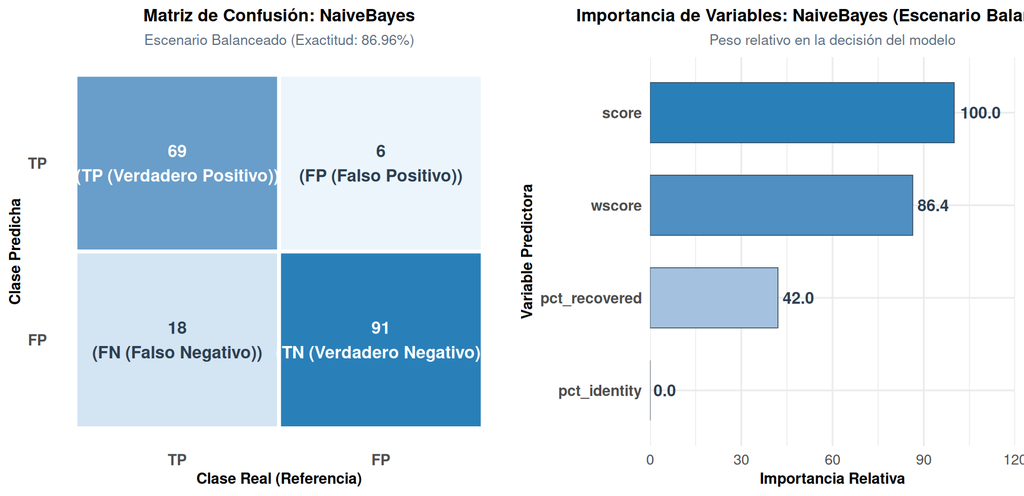

```
Hiperparámetros seleccionados en validación cruzada para NaiveBayes (Escenario Balanceado):
  fL usekernel adjust
2  0      TRUE      1
```

**SVM_Polinomial**

SVM_Polinomial (Escenario Balanceado): F1: 0.859 | ROC-AUC: 0.934 | Exactitud Bal.: 87.14% | Sensibilidad: 80.46% | Especificidad: 93.81% | Precisión: 92.11% | FDR: 7.89%

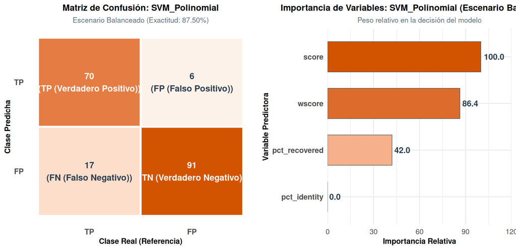

```
Hiperparámetros seleccionados en validación cruzada para SVM_Polinomial (Escenario Balanceado):
   degree scale C
18      2   0.1 1
```

**Youden_score**

Youden_score (Escenario Balanceado): F1: 0.867 | ROC-AUC: 0.933 | Exactitud Bal.: 87.77% | Sensibilidad: 82.76% | Especificidad: 92.78% | Precisión: 91.14% | FDR: 8.86%

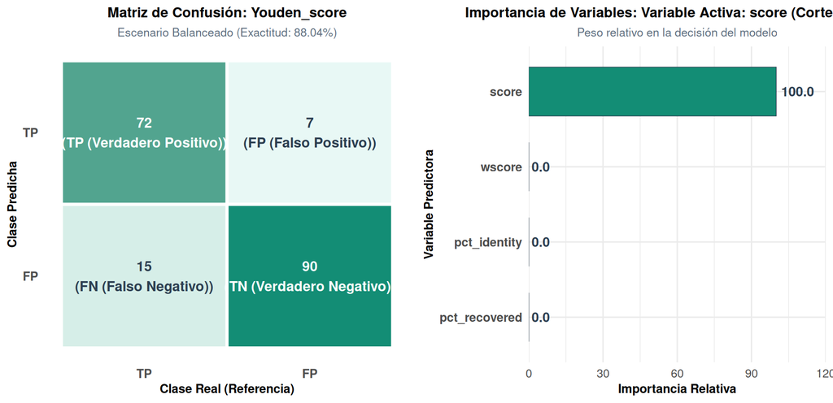

**Ensamble_Stacking**

Ensamble_Stacking (Escenario Balanceado): F1: 0.873 | ROC-AUC: 0.932 | Exactitud Bal.: 88.29% | Sensibilidad: 82.76% | Especificidad: 93.81% | Precisión: 92.31% | FDR: 7.69%

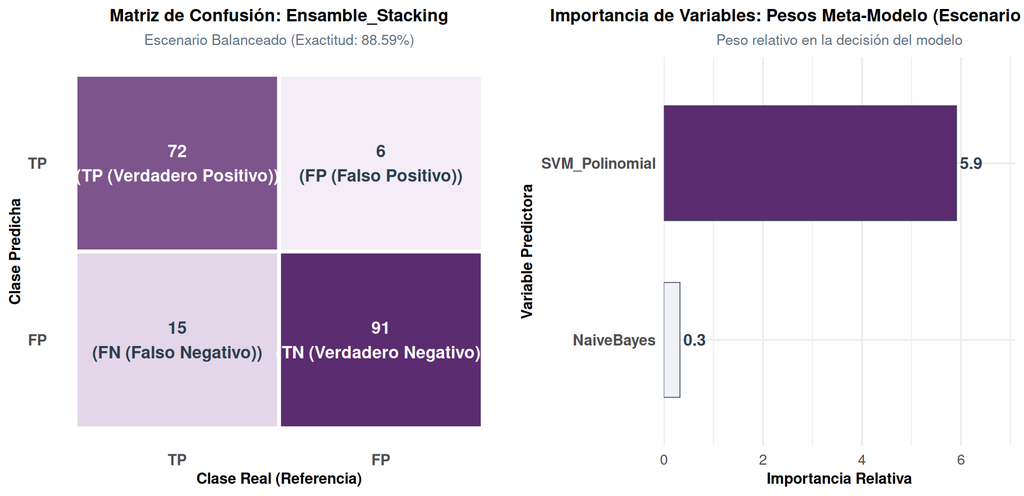

```
Resumen del Meta-Modelo GLM Stacking (Escenario Balanceado):
The following models were ensembled: NaiveBayes, SVM_Polinomial

caret::train model:
Generalized Linear Model

184 samples
  2 predictor
  2 classes: 'TP', 'FP'

No pre-processing
Resampling: Cross-Validated (5 fold)
Summary of sample sizes: 146, 148, 146, 148, 148
Resampling results:

  ROC        Sens       Spec
  0.9320382  0.8281046  0.9373684


Final model:

Call:  NULL

Coefficients:
   (Intercept)      NaiveBayes  SVM_Polinomial
       -3.3170          0.3254          5.9107

Degrees of Freedom: 183 Total (i.e. Null);  181 Residual
Null Deviance:      254.5
Residual Deviance: 122.1    AIC: 128.1
```

**ElasticNet**

ElasticNet (Escenario Balanceado): F1: 0.844 | ROC-AUC: 0.930 | Exactitud Bal.: 85.25% | Sensibilidad: 83.91% | Especificidad: 86.60% | Precisión: 84.88% | FDR: 15.12%

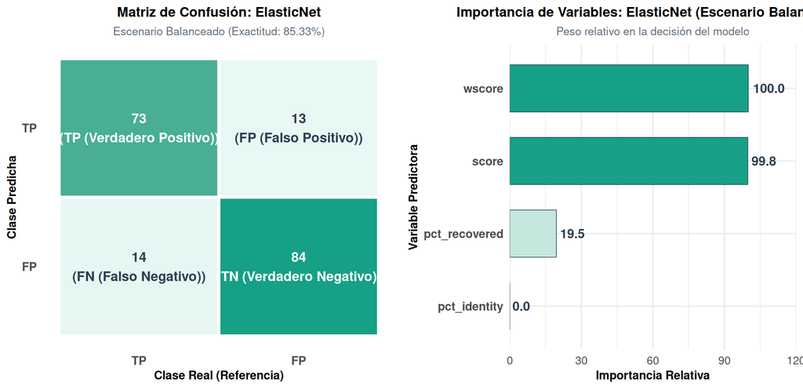

```
Hiperparámetros óptimos Elastic Net (Escenario Balanceado): alpha = 0.1 | lambda = 0.168
5 x 1 sparse Matrix of class "dgCMatrix"
              s=0.1679815
(Intercept)     0.0008043
pct_recovered  -0.3684994
pct_identity   -0.3542977
score          -0.4268274
wscore         -0.4269720
```

**Youden_wscore**

Youden_wscore (Escenario Balanceado): F1: 0.859 | ROC-AUC: 0.928 | Exactitud Bal.: 86.80% | Sensibilidad: 83.91% | Especificidad: 89.69% | Precisión: 87.95% | FDR: 12.05%

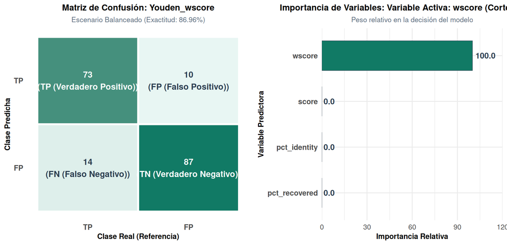

**Red_Neuronal**

Red_Neuronal (Escenario Balanceado): F1: 0.864 | ROC-AUC: 0.927 | Exactitud Bal.: 87.31% | Sensibilidad: 83.91% | Especificidad: 90.72% | Precisión: 89.02% | FDR: 10.98%

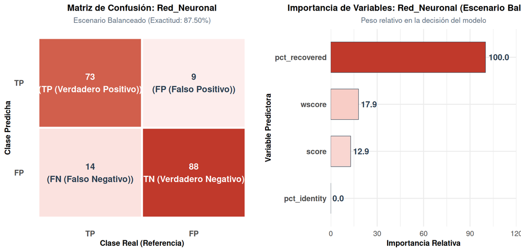

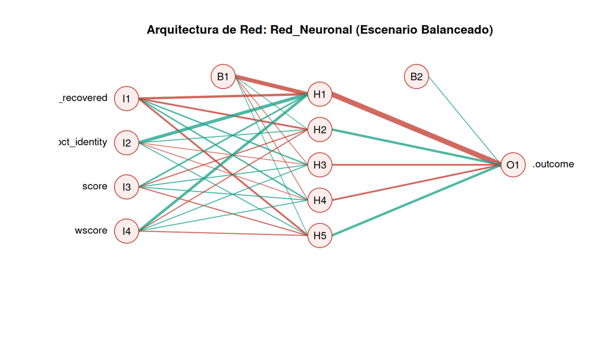

```
Parámetros de Red_Neuronal (nnet - Escenario Balanceado): topología = 4 - 5 - 1 | size = 5 | decay = 0.1
```

**SVM_Lineal**

SVM_Lineal (Escenario Balanceado): F1: 0.854 | ROC-AUC: 0.925 | Exactitud Bal.: 86.28% | Sensibilidad: 83.91% | Especificidad: 88.66% | Precisión: 86.90% | FDR: 13.10%

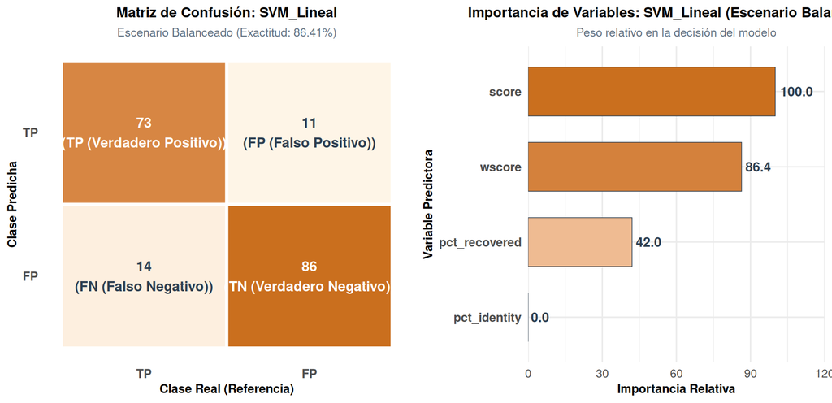

```
Hiperparámetros seleccionados en validación cruzada para SVM_Lineal (Escenario Balanceado):
  C
1 1
```

**MLP_Regularizado**

MLP_Regularizado (Escenario Balanceado): F1: 0.857 | ROC-AUC: 0.923 | Exactitud Bal.: 86.74% | Sensibilidad: 82.76% | Especificidad: 90.72% | Precisión: 88.89% | FDR: 11.11%

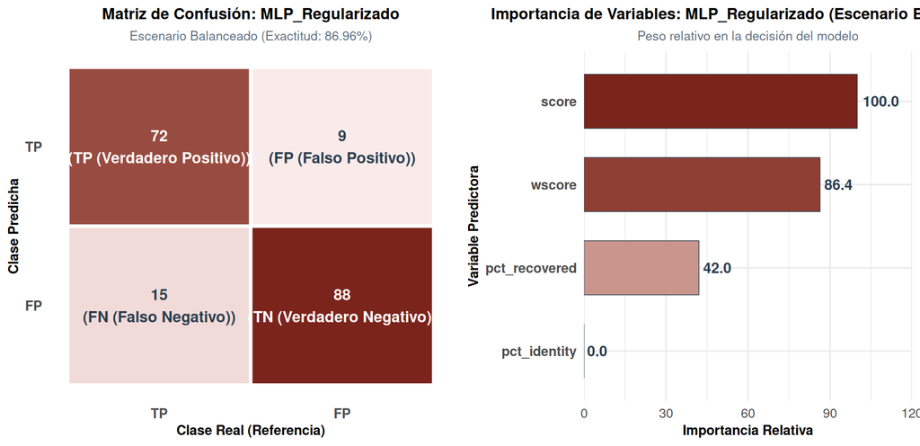

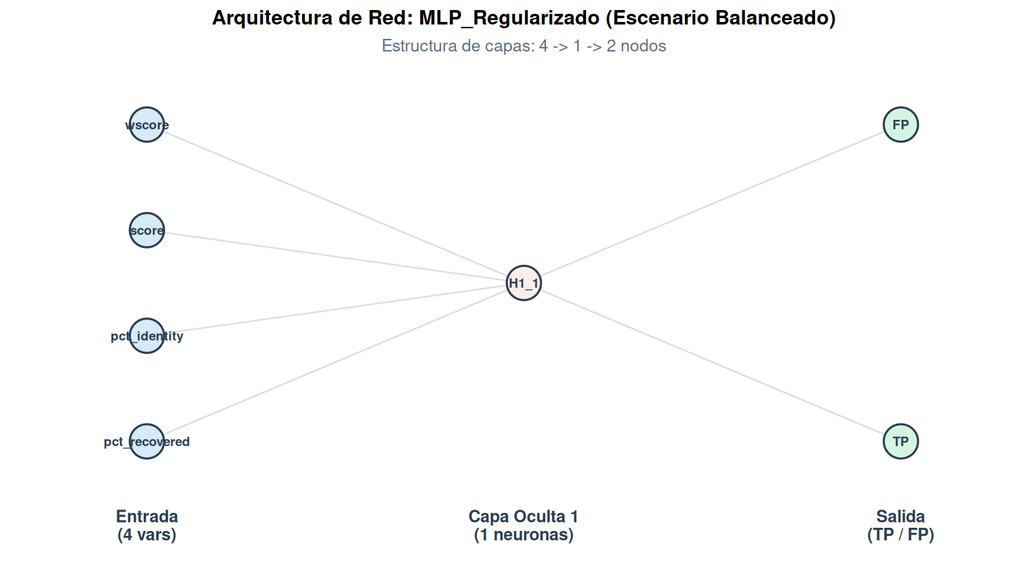

```
Hiperparámetros seleccionados en validación cruzada para MLP_Regularizado (Escenario Balanceado):
  layer1 layer2 layer3 decay
2      1      0      0 1e-04
```

**Red_Neuronal_Bag**

Red_Neuronal_Bag (Escenario Balanceado): F1: 0.862 | ROC-AUC: 0.923 | Exactitud Bal.: 87.26% | Sensibilidad: 82.76% | Especificidad: 91.75% | Precisión: 90.00% | FDR: 10.00%

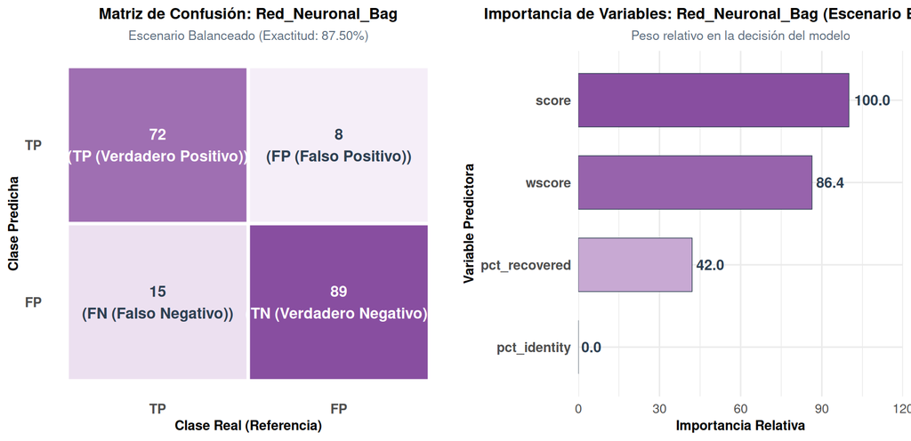

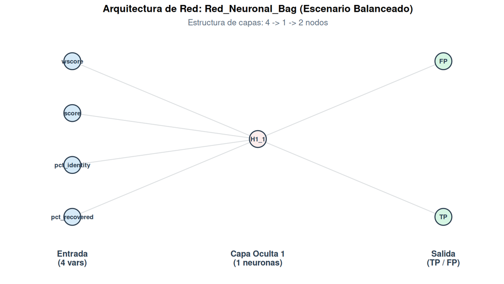

```
Parámetros de Red_Neuronal_Bag (avNNet - Escenario Balanceado): sub-redes = 5 | topología = 4 - 1 - 2 | size = 1 | decay = 0.1
```

**MLP**

MLP (Escenario Balanceado): F1: 0.852 | ROC-AUC: 0.923 | Exactitud Bal.: 86.56% | Sensibilidad: 79.31% | Especificidad: 93.81% | Precisión: 92.00% | FDR: 8.00%

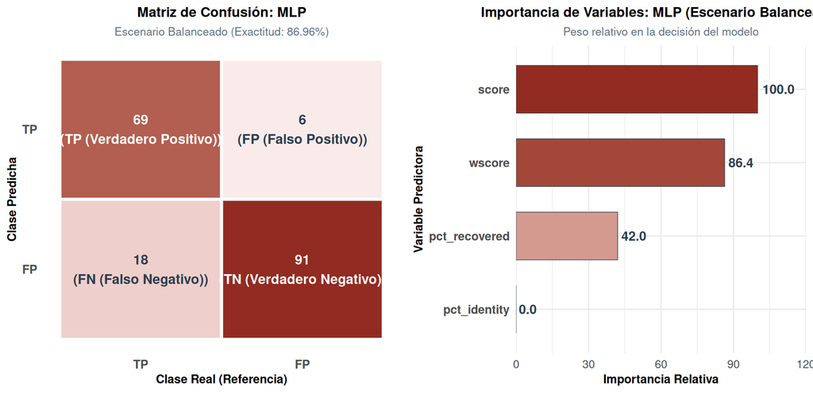

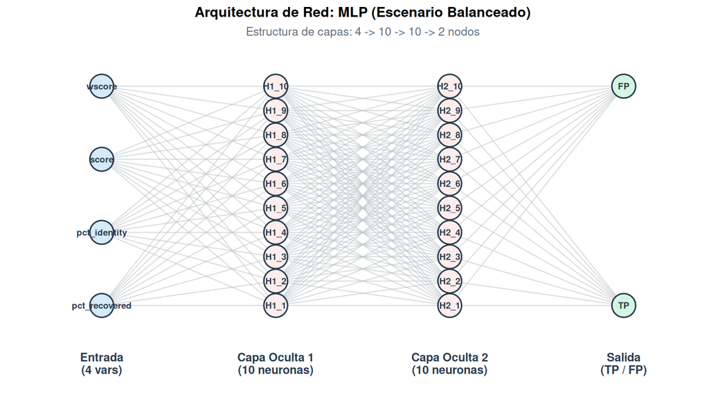

```
Hiperparámetros seleccionados en validación cruzada para MLP (Escenario Balanceado):
  layer1 layer2 layer3
3     10     10      0
```

**LDA**

LDA (Escenario Balanceado): F1: 0.857 | ROC-AUC: 0.922 | Exactitud Bal.: 86.74% | Sensibilidad: 82.76% | Especificidad: 90.72% | Precisión: 88.89% | FDR: 11.11%

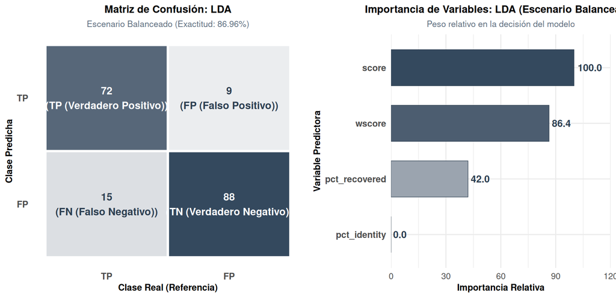

```
Coeficientes discriminantes lineales LD1 (Escenario Balanceado):
                     LD1
pct_recovered  0.5307763
pct_identity   1.6877497
score         -0.1167388
wscore        -3.5595491
```

**Weighted_Heuristic**

Weighted_Heuristic (Escenario Balanceado): F1: 0.880 | ROC-AUC: 0.921 | Exactitud Bal.: 88.86% | Sensibilidad: 83.91% | Especificidad: 93.81% | Precisión: 92.41% | FDR: 7.59%

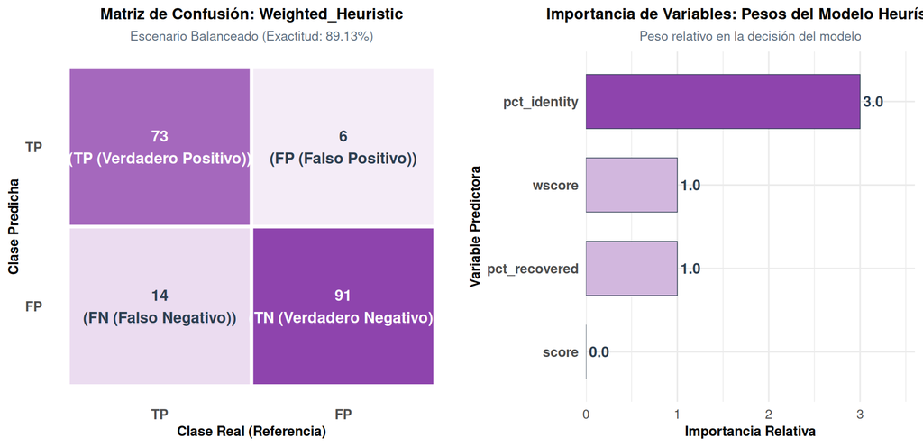

**GBM**

GBM (Escenario Balanceado): F1: 0.857 | ROC-AUC: 0.920 | Exactitud Bal.: 86.74% | Sensibilidad: 82.76% | Especificidad: 90.72% | Precisión: 88.89% | FDR: 11.11%

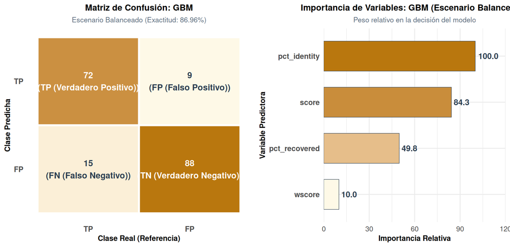

```
Hiperparámetros seleccionados en validación cruzada para GBM (Escenario Balanceado):
  n.trees interaction.depth shrinkage n.minobsinnode
1      50                 1      0.05             10
```

**QDA**

QDA (Escenario Balanceado): F1: 0.854 | ROC-AUC: 0.920 | Exactitud Bal.: 86.28% | Sensibilidad: 83.91% | Especificidad: 88.66% | Precisión: 86.90% | FDR: 13.10%

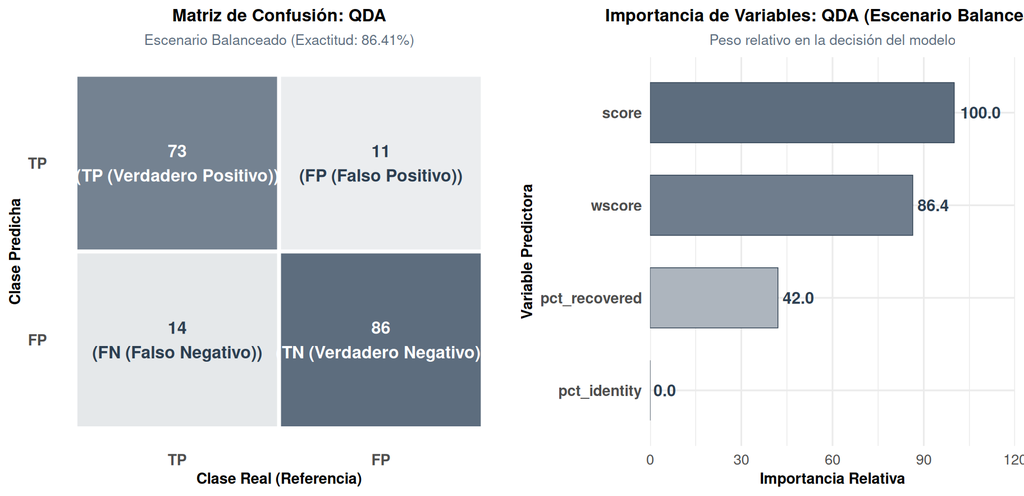

```
Hiperparámetros seleccionados en validación cruzada para QDA (Escenario Balanceado):
  parameter
1      none
```

**XGBoost**

XGBoost (Escenario Balanceado): F1: 0.831 | ROC-AUC: 0.920 | Exactitud Bal.: 84.50% | Sensibilidad: 79.31% | Especificidad: 89.69% | Precisión: 87.34% | FDR: 12.66%

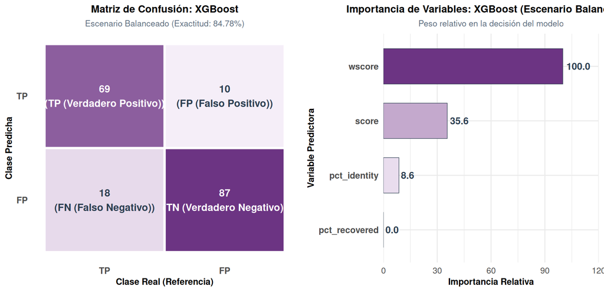

```
Hiperparámetros seleccionados en validación cruzada para XGBoost (Escenario Balanceado):
  nrounds max_depth eta gamma colsample_bytree min_child_weight subsample
7      50         1 0.3     0              0.6                1         1
```

**Youden_pct_recovered**

Youden_pct_recovered (Escenario Balanceado): F1: 0.865 | ROC-AUC: 0.914 | Exactitud Bal.: 87.37% | Sensibilidad: 85.06% | Especificidad: 89.69% | Precisión: 88.10% | FDR: 11.90%

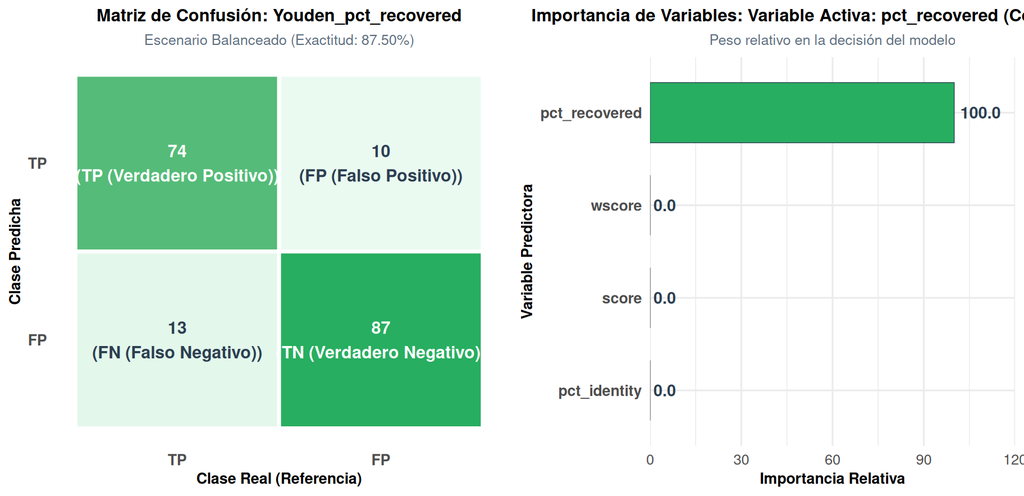

**KNN**

KNN (Escenario Balanceado): F1: 0.826 | ROC-AUC: 0.909 | Exactitud Bal.: 83.99% | Sensibilidad: 79.31% | Especificidad: 88.66% | Precisión: 86.25% | FDR: 13.75%

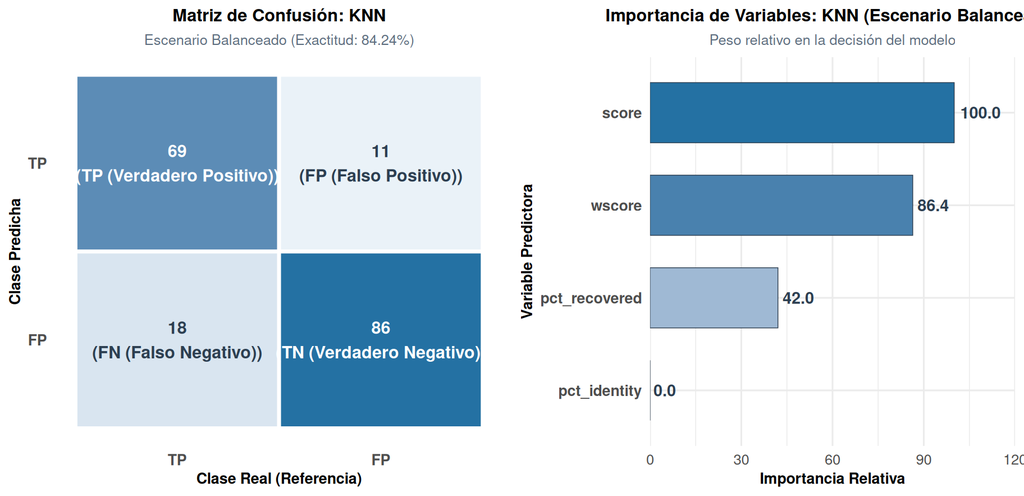

```
Hiperparámetros seleccionados en validación cruzada para KNN (Escenario Balanceado):
  k
3 9
```

**SVM_Radial**

SVM_Radial (Escenario Balanceado): F1: 0.838 | ROC-AUC: 0.904 | Exactitud Bal.: 85.41% | Sensibilidad: 77.01% | Especificidad: 93.81% | Precisión: 91.78% | FDR: 8.22%

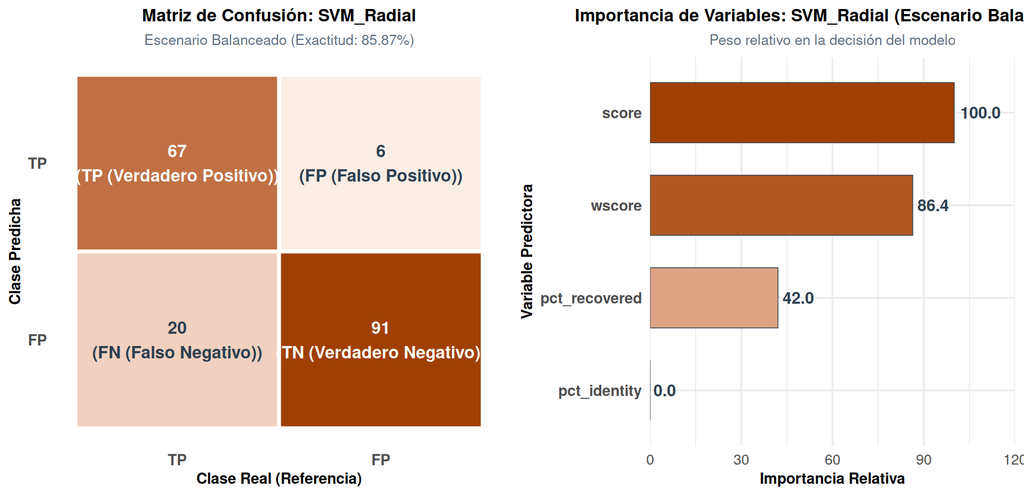

```
Hiperparámetros seleccionados en validación cruzada para SVM_Radial (Escenario Balanceado):
     sigma   C
2 1.842564 0.5
```

**RandomForest**

RandomForest (Escenario Balanceado): F1: 0.826 | ROC-AUC: 0.902 | Exactitud Bal.: 83.99% | Sensibilidad: 79.31% | Especificidad: 88.66% | Precisión: 86.25% | FDR: 13.75%

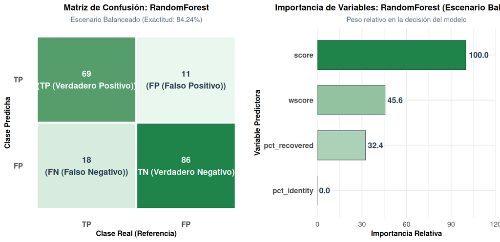

```
Hiperparámetros seleccionados en validación cruzada para RandomForest (Escenario Balanceado):
  mtry
1    2
```

**Youden_pct_identity**

Youden_pct_identity (Escenario Balanceado): F1: 0.840 | ROC-AUC: 0.901 | Exactitud Bal.: 86.21% | Sensibilidad: 72.41% | Especificidad: 100.00% | Precisión: 100.00% | FDR: 0.00%

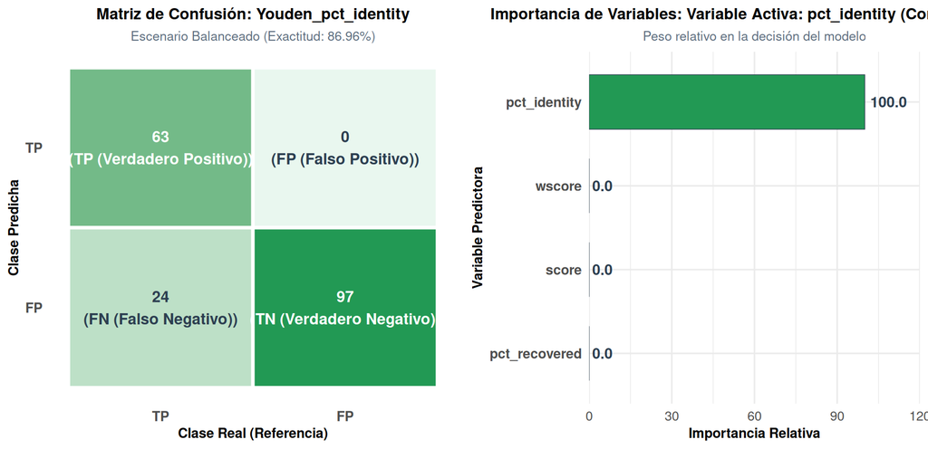

**Bagging_Arboles**

Bagging_Arboles (Escenario Balanceado): F1: 0.788 | ROC-AUC: 0.894 | Exactitud Bal.: 80.26% | Sensibilidad: 77.01% | Especificidad: 83.51% | Precisión: 80.72% | FDR: 19.28%

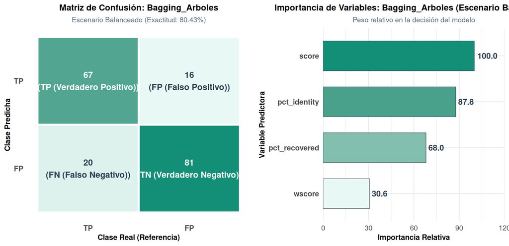

```
Hiperparámetros seleccionados en validación cruzada para Bagging_Arboles (Escenario Balanceado):
  parameter
1      none
```

**CART**